# Siegel_Unsupervised_Learning

### 3.3 hierarchical Clustering

The following code is a hierarchical clustering code modified from a class example to run through and display the various linkage methods.

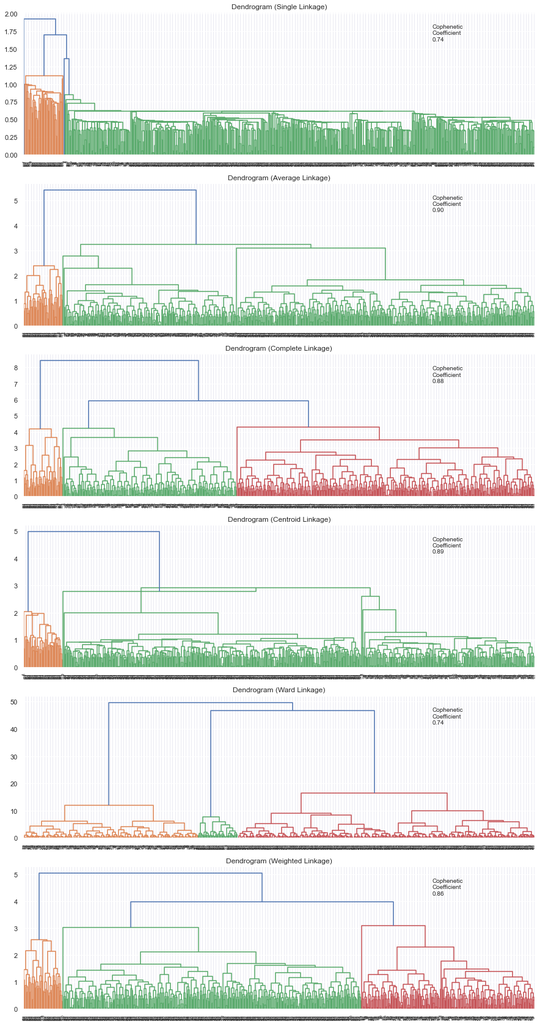

```python
# List of all linkage methods to check
methods = ['single',
           'average',
           'complete',
           'centroid',
           'ward',
          'weighted']

# Calculate the pairwise distance form the dataset to be used in the cophenetic correlation calculation
#pw_distance = pdist(credit_scaled)

# Create lists to save results of coph calculation
compare_cols = ['Linkage', 'Cophenetic Coefficient']
# compare = []

# Create a subplot image
fig, axs = plt.subplots(len(methods), 1, figsize=(15, 30))

# Enumerate through the list of all methods above
# Get linkage, plot dendrogram, calculate cophenetic coefficient
for i, method in enumerate(methods):

    Z = linkage(datascaled, metric='euclidean', method=method)

    dendrogram(Z, ax=axs[i]);
    axs[i].set_title(f'Dendrogram ({method.capitalize()} Linkage)')
    coph_corr, coph_dist = cophenet(Z, pdist(datascaled))
    axs[i].annotate(f'Cophenetic\nCoefficient\n{coph_corr:0.2f}',
                    (0.80, 0.80),
                    xycoords='axes fraction')
#     compare.append([method, coph_corr])
```

Ward Linkage and complete linage show the best results on the dendogram, each with 3 clusters.

#### 3.3.1 Ward Linkage

```python
model = AgglomerativeClustering(n_clusters=3, affinity='euclidean',  linkage='ward')
model.fit(datascaled)
```

```
AgglomerativeClustering(n_clusters=3)
```

```python
dataHW = data.copy()
dataHW['GROUP'] = model.labels_
```

```python
datastatsHW = dataHW.groupby(['GROUP'])
datastatsHW = datastatsHW.mean()
datastatsHW['Number_In_Group'] = dataHW['GROUP'].value_counts()
datastatsHW
```

| GROUP | Avg_Credit_Limit | Total_Credit_Cards | Total_visits_bank | Total_visits_online | Total_calls_made | Number_In_Group |
| --- | --- | --- | --- | --- | --- | --- |
| 0 | 34143.236074 | 5.519894 | 3.488064 | 0.978780 | 1.986737 | 377 |
| 1 | 12216.216216 | 2.423423 | 0.950450 | 3.554054 | 6.878378 | 222 |
| 2 | 141040.000000 | 8.740000 | 0.600000 | 10.900000 | 1.080000 | 50 |

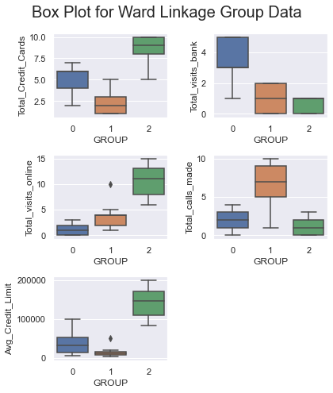

```python
j=1  # to be used as index for figure location
plt.figure(figsize=(6,7))
plt.suptitle('Box Plot for Ward Linkage Group Data', fontsize=20)
for i in ['Total_Credit_Cards','Total_visits_bank', 'Total_visits_online', 'Total_calls_made', 'Avg_Credit_Limit']:
    plt.subplot(3,2,j)
    sns.boxplot(y=i,x="GROUP",data=dataHW)
    plt.tight_layout()
    j=j+1
```

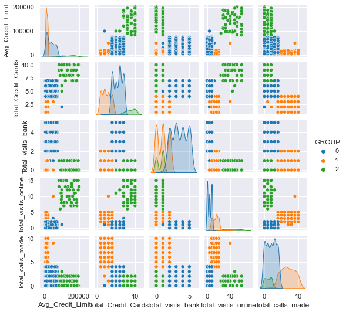

```python
sns.pairplot(dataHW, hue='GROUP', height=1.5,aspect=1, diag_kind='kde', palette='tab10')
#sns.color_palette("tab10")
```

#### 3.3.3 Complete Linkage

```python
model = AgglomerativeClustering(n_clusters=3, affinity='euclidean',  linkage='complete')
model.fit(datascaled)
```

```
AgglomerativeClustering(linkage='complete', n_clusters=3)
```

```python
dataHC = data.copy()
dataHC['GROUP'] = model.labels_
```

```python
datastatsHC = dataHC.groupby(['GROUP'])
datastatsHC = datastatsHC.mean()
datastatsHC['Number_In_Group'] = dataHC['GROUP'].value_counts()
datastatsHC
```

| GROUP | Avg_Credit_Limit | Total_Credit_Cards | Total_visits_bank | Total_visits_online | Total_calls_made | Number_In_Group |
| --- | --- | --- | --- | --- | --- | --- |
| 0 | 34010.582011 | 5.515873 | 3.486772 | 0.984127 | 1.992063 | 378 |
| 1 | 141040.000000 | 8.740000 | 0.600000 | 10.900000 | 1.080000 | 50 |
| 2 | 12343.891403 | 2.416290 | 0.941176 | 3.556561 | 6.891403 | 221 |

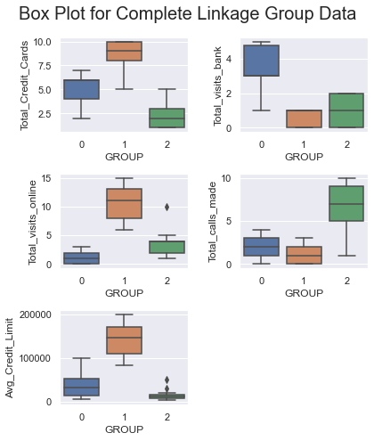

```python
j=1  # to be used as index for figure location
plt.figure(figsize=(6,7))
plt.suptitle('Box Plot for Complete Linkage Group Data', fontsize=20)
for i in ['Total_Credit_Cards','Total_visits_bank', 'Total_visits_online', 'Total_calls_made', 'Avg_Credit_Limit']:
    plt.subplot(3,2,j)
    sns.boxplot(y=i,x="GROUP",data=dataHC)
    plt.tight_layout()
    j=j+1
```

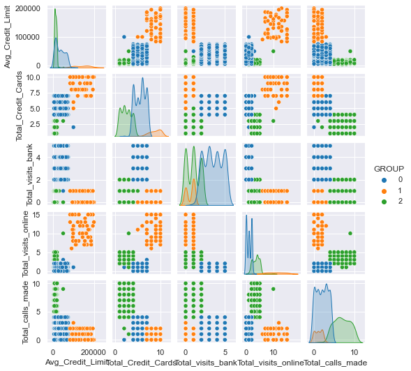

```python
sns.pairplot(dataHC, hue='GROUP', height=1.5,aspect=1, diag_kind='kde', palette='tab10')
```

**Summary of Hierarchical Clustering**

- Ward Linkage and complete linage show the best results on the dendogram, each with 3 clusters.
- The grouping values for both methods are similar.